# Results: titanic_eda_in_SAS.sas

EDA in SAS on Titanic data by Michael Eryan

General data set examination and preparation

Add the Minor variable and load the data set into macro variables to avoid typos.

The data is a sample and incomplete, so we cannot make any generalizations or definitive conclusions. My goal is just exploration, observation and some speculation.

Automatically produced summary of the data set

The input data set is titanic_data.csv.

Proc Contents provides all the info about the data set.

The CONTENTS Procedure

| Data Set Name | WORK.TITANIC | Observations | 891 |
| --- | --- | --- | --- |
| Member Type | DATA | Variables | 13 |
| Engine | V9 | Indexes | 0 |
| Created | 02/04/2017 08:28:10 | Observation Length | 152 |
| Last Modified | 02/04/2017 08:28:10 | Deleted Observations | 0 |
| Protection |  | Compressed | NO |
| Data Set Type |  | Sorted | NO |
| Label |  |  |  |
| Data Representation | SOLARIS_X86_64, LINUX_X86_64, ALPHA_TRU64, LINUX_IA64 |  |  |
| Encoding | utf-8 Unicode (UTF-8) |  |  |

| Alphabetic List of Variables and Attributes # | Alphabetic List of Variables and Attributes Variable | Alphabetic List of Variables and Attributes Type | Alphabetic List of Variables and Attributes Len | Alphabetic List of Variables and Attributes Format | Alphabetic List of Variables and Attributes Informat |
| --- | --- | --- | --- | --- | --- |
| 6 | Age | Num | 8 | BEST12. | BEST32. |
| 11 | Cabin | Char | 4 | $4. | $4. |
| 12 | Embarked | Char | 1 | $1. | $1. |
| 10 | Fare | Num | 8 | BEST12. | BEST32. |
| 4 | Name | Char | 57 | $57. | $57. |
| 8 | Parch | Num | 8 | BEST12. | BEST32. |
| 1 | PassengerId | Num | 8 | BEST12. | BEST32. |
| 3 | Pclass | Num | 8 | BEST12. | BEST32. |
| 5 | Sex | Char | 6 | $6. | $6. |
| 7 | SibSp | Num | 8 | BEST12. | BEST32. |
| 2 | Survived | Num | 8 | BEST12. | BEST32. |
| 9 | Ticket | Char | 16 | $16. | $16. |
| 13 | minor | Num | 8 |  |  |

Print a few rows of the data set

| Obs | PassengerId | Survived | Pclass | Name | Sex | Age | SibSp | Parch | Ticket | Fare | Cabin | Embarked | minor |
| --- | --- | --- | --- | --- | --- | --- | --- | --- | --- | --- | --- | --- | --- |
| 1 | 1 | 0 | 3 | Braund, Mr. Owen Harris | male | 22 | 1 | 0 | A/5 21171 | 7.25 |  | S | 0 |
| 2 | 2 | 1 | 1 | Cumings, Mrs. John Bradley (Florence Briggs Thayer) | female | 38 | 1 | 0 | PC 17599 | 71.2833 | C85 | C | 0 |
| 3 | 3 | 1 | 3 | Heikkinen, Miss. Laina | female | 26 | 0 | 0 | STON/O2. 3101282 | 7.925 |  | S | 0 |
| 4 | 4 | 1 | 1 | Futrelle, Mrs. Jacques Heath (Lily May Peel) | female | 35 | 1 | 0 | 113803 | 53.1 | C123 | S | 0 |
| 5 | 5 | 0 | 3 | Allen, Mr. William Henry | male | 35 | 0 | 0 | 373450 | 8.05 |  | S | 0 |
| 6 | 6 | 0 | 3 | Moran, Mr. James | male | . | 0 | 0 | 330877 | 8.4583 |  | Q | . |
| 7 | 7 | 0 | 1 | McCarthy, Mr. Timothy J | male | 54 | 0 | 0 | 17463 | 51.8625 | E46 | S | 0 |
| 8 | 8 | 0 | 3 | Palsson, Master. Gosta Leonard | male | 2 | 3 | 1 | 349909 | 21.075 |  | S | 1 |
| 9 | 9 | 1 | 3 | Johnson, Mrs. Oscar W (Elisabeth Vilhelmina Berg) | female | 27 | 0 | 2 | 347742 | 11.1333 |  | S | 0 |
| 10 | 10 | 1 | 2 | Nasser, Mrs. Nicholas (Adele Achem) | female | 14 | 1 | 0 | 237736 | 30.0708 |  | C | 1 |

Print a summary of all the numerical variables in the data

The MEANS Procedure

| Variable | N | N Miss | Minimum | Mean | Median | Maximum | Range | Std Dev |
| --- | --- | --- | --- | --- | --- | --- | --- | --- |
| PassengerId Survived Pclass Age SibSp Parch Fare minor | 891 891 891 714 891 891 891 714 | 0 0 0 177 0 0 0 177 | 1.00 0.00 1.00 0.42 0.00 0.00 0.00 0.00 | 446.00 0.38 2.31 29.70 0.52 0.38 32.20 0.16 | 446.00 0.00 3.00 28.00 0.00 0.00 14.45 0.00 | 891.00 1.00 3.00 80.00 8.00 6.00 512.33 1.00 | 890.00 1.00 2.00 79.58 8.00 6.00 512.33 1.00 | 257.35 0.49 0.84 14.53 1.10 0.81 49.69 0.37 |

Univariate Plots and Analysis

Single variable tabulations

| Survived | count |
| --- | --- |
| 0 | 549 |
| 1 | 342 |

| Sex | count |
| --- | --- |
| female | 314 |
| male | 577 |

| Pclass | count |
| --- | --- |
| 1 | 216 |
| 2 | 184 |
| 3 | 491 |

| minor | count |
| --- | --- |
| . | 177 |
| 0 | 601 |
| 1 | 113 |

Bar Charts

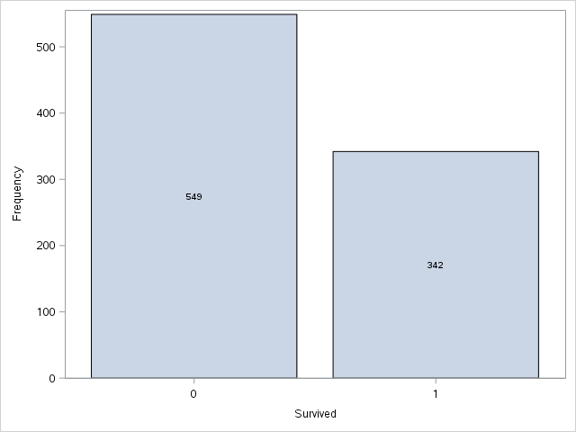

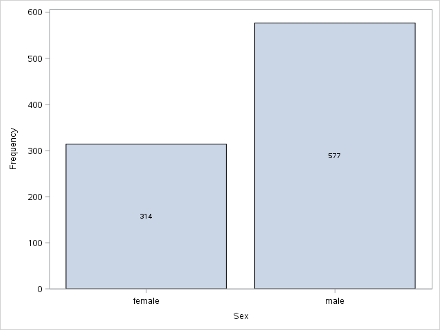

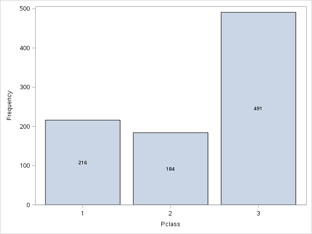

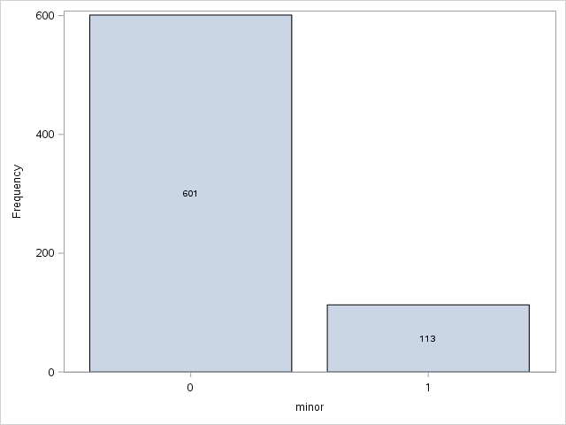

Observations: more males than females, more died than survived, 3 is the poorest socio-econ class.

Fancier bar charts - Counts and Proportions of Gender vs Survival.

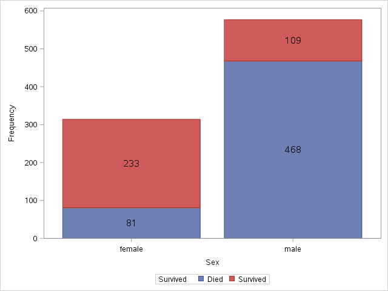

Histogram with Density Plot of Age

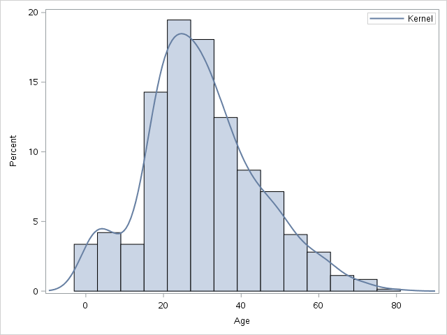

Bivariate Plots and Analysis

Let’s facet Age by Sex and Survival

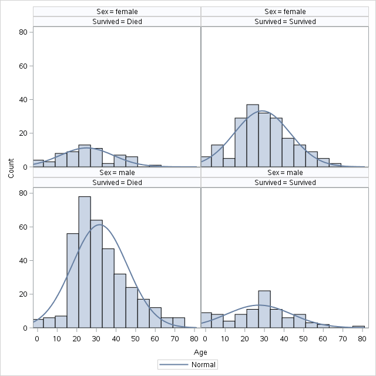

Almost mirror image, but is it statistically significant? Let’s test by Anova.

First, let's look at the mean of Age by gender*survival.

| Sex | Survived | mean_age |
| --- | --- | --- |
| male | 0 | 31.61806 |
| female | 0 | 25.04688 |
| male | 1 | 27.27602 |
| female | 1 | 28.84772 |

For survivors, the means are pretty close, but not so for dead. But is it significant?

The ANOVA Procedure

Dependent Variable: Age

| Source | DF | Sum of Squares | Mean Square | F Value | Pr > F |
| --- | --- | --- | --- | --- | --- |
| Model | 1 | 156.05845 | 156.05845 | 0.70 | 0.4043 |
| Error | 288 | 64444.39050 | 223.76524 |  |  |
| Corrected Total | 289 | 64600.44895 |  |  |  |

Age difference is not significant among the survivors.

The ANOVA Procedure

Dependent Variable: Age

| Source | DF | Sum of Squares | Mean Square | F Value | Pr > F |
| --- | --- | --- | --- | --- | --- |
| Model | 1 | 2346.40740 | 2346.40740 | 11.99 | 0.0006 |
| Error | 422 | 82612.59201 | 195.76444 |  |  |
| Corrected Total | 423 | 84958.99941 |  |  |  |

But definitely significant among the dead.

The men who died were older than the women who died.

Let’s look closer at survival * sex * pclass

The FREQ Procedure

| Survived | Frequency | Percent | Cumulative Frequency | Cumulative Percent |
| --- | --- | --- | --- | --- |
| Died | 549 | 61.62 | 549 | 61.62 |
| Survived | 342 | 38.38 | 891 | 100.00 |

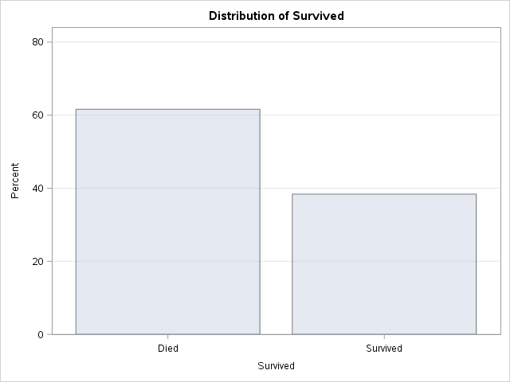

| Sex | Frequency | Percent | Cumulative Frequency | Cumulative Percent |
| --- | --- | --- | --- | --- |
| female | 314 | 35.24 | 314 | 35.24 |
| male | 577 | 64.76 | 891 | 100.00 |

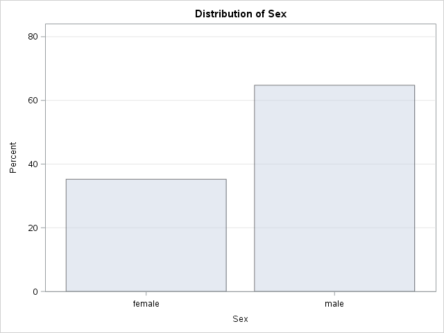

| Pclass | Frequency | Percent | Cumulative Frequency | Cumulative Percent |
| --- | --- | --- | --- | --- |
| 1 | 216 | 24.24 | 216 | 24.24 |
| 2 | 184 | 20.65 | 400 | 44.89 |
| 3 | 491 | 55.11 | 891 | 100.00 |

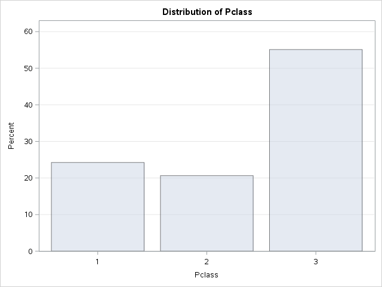

| Frequency Percent Row Pct Col Pct |
| --- |

| Table of Sex by Survived Sex | Table of Sex by Survived Survived Died | Table of Sex by Survived Survived | Table of Sex by Survived Survived Total |
| --- | --- | --- | --- |
| female | 81 9.09 25.80 14.75 | 233 26.15 74.20 68.13 | 314 35.24 |
| male | 468 52.53 81.11 85.25 | 109 12.23 18.89 31.87 | 577 64.76 |
| Total | 549 61.62 | 342 38.38 | 891 100.00 |

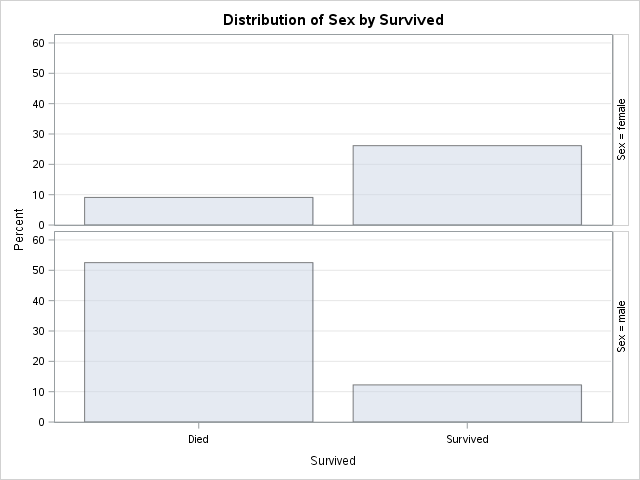

| Frequency Percent Row Pct Col Pct |
| --- |

| Table of Pclass by Survived Pclass | Table of Pclass by Survived Survived Died | Table of Pclass by Survived Survived | Table of Pclass by Survived Survived Total |
| --- | --- | --- | --- |
| 1 | 80 8.98 37.04 14.57 | 136 15.26 62.96 39.77 | 216 24.24 |
| 2 | 97 10.89 52.72 17.67 | 87 9.76 47.28 25.44 | 184 20.65 |
| 3 | 372 41.75 75.76 67.76 | 119 13.36 24.24 34.80 | 491 55.11 |
| Total | 549 61.62 | 342 38.38 | 891 100.00 |

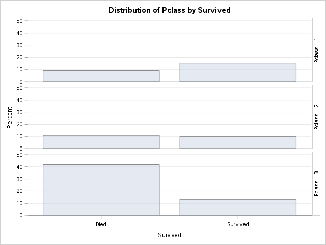

We see that there might be a link between being male and not surviving.

Let's do a test for association (contingency table test).

Hypothesis: There is an association between sex and survival also try class and age.

The FREQ Procedure

| Frequency Expected Cell Chi-Square Row Pct |
| --- |

| Table of Sex by Survived Sex | Table of Sex by Survived Survived Died | Table of Sex by Survived Survived | Table of Sex by Survived Survived Total |
| --- | --- | --- | --- |
| female | 81 193.47 65.386 25.80 | 233 120.53 104.96 74.20 | 314 |
| male | 468 355.53 35.583 81.11 | 109 221.47 57.12 18.89 | 577 |
| Total | 549 | 342 | 891 |

Statistics for Table of Sex by Survived

| Statistic | DF | Value | Prob |
| --- | --- | --- | --- |
| Chi-Square | 1 | 263.0506 | <.0001 |
| Likelihood Ratio Chi-Square | 1 | 268.8512 | <.0001 |
| Continuity Adj. Chi-Square | 1 | 260.7170 | <.0001 |
| Mantel-Haenszel Chi-Square | 1 | 262.7553 | <.0001 |
| Phi Coefficient |  | -0.5434 |  |
| Contingency Coefficient |  | 0.4774 |  |
| Cramer's V |  | -0.5434 |  |

| Fisher's Exact Test |  |
| --- | --- |
| Cell (1,1) Frequency (F) | 81 |
| Left-sided Pr <= F | <.0001 |
| Right-sided Pr >= F | 1.0000 |
| Table Probability (P) | <.0001 |
| Two-sided Pr <= P | <.0001 |

| Odds Ratio and Relative Risks Statistic | Odds Ratio and Relative Risks Value | Odds Ratio and Relative Risks 95% Confidence Limits | Odds Ratio and Relative Risks 95% Confidence Limits |
| --- | --- | --- | --- |
| Odds Ratio | 0.0810 | 0.0583 | 0.1124 |
| Relative Risk (Column 1) | 0.3180 | 0.2626 | 0.3852 |
| Relative Risk (Column 2) | 3.9280 | 3.2770 | 4.7084 |

Sample Size = 891

| Frequency Expected Cell Chi-Square Row Pct |
| --- |

| Table of Pclass by Survived Pclass | Table of Pclass by Survived Survived Died | Table of Pclass by Survived Survived | Table of Pclass by Survived Survived Total |
| --- | --- | --- | --- |
| 1 | 80 133.09 21.178 37.04 | 136 82.909 33.997 62.96 | 216 |
| 2 | 97 113.37 2.3647 52.72 | 87 70.626 3.796 47.28 | 184 |
| 3 | 372 302.54 15.95 75.76 | 119 188.46 25.603 24.24 | 491 |
| Total | 549 | 342 | 891 |

Statistics for Table of Pclass by Survived

| Statistic | DF | Value | Prob |
| --- | --- | --- | --- |
| Chi-Square | 2 | 102.8890 | <.0001 |
| Likelihood Ratio Chi-Square | 2 | 103.5471 | <.0001 |
| Mantel-Haenszel Chi-Square | 1 | 101.9668 | <.0001 |
| Phi Coefficient |  | 0.3398 |  |
| Contingency Coefficient |  | 0.3217 |  |
| Cramer's V |  | 0.3398 |  |

Sample Size = 891

Odds ratio (top row/bottom row) is significant at 0.08 - women are more likely than men to survive.

0.08 says that a female has about 8 of the odds of dying compared to a male.

Alternatively males have 92 lower odds of surviving than females.

Does this pattern hold among the minors?

The FREQ Procedure

| Frequency Expected Cell Chi-Square Row Pct |
| --- |

| Table of Sex by Survived Sex | Table of Sex by Survived Survived Died | Table of Sex by Survived Survived | Table of Sex by Survived Survived Total |
| --- | --- | --- | --- |
| female | 17 25.31 2.7283 30.91 | 38 29.69 2.3257 69.09 | 55 |
| male | 35 26.69 2.5871 60.34 | 23 31.31 2.2054 39.66 | 58 |
| Total | 52 | 61 | 113 |

Statistics for Table of Sex by Survived

| Statistic | DF | Value | Prob |
| --- | --- | --- | --- |
| Chi-Square | 1 | 9.8466 | 0.0017 |
| Likelihood Ratio Chi-Square | 1 | 10.0085 | 0.0016 |
| Continuity Adj. Chi-Square | 1 | 8.6973 | 0.0032 |
| Mantel-Haenszel Chi-Square | 1 | 9.7595 | 0.0018 |
| Phi Coefficient |  | -0.2952 |  |
| Contingency Coefficient |  | 0.2831 |  |
| Cramer's V |  | -0.2952 |  |

| Fisher's Exact Test |  |
| --- | --- |
| Cell (1,1) Frequency (F) | 17 |
| Left-sided Pr <= F | 0.0015 |
| Right-sided Pr >= F | 0.9996 |
| Table Probability (P) | 0.0011 |
| Two-sided Pr <= P | 0.0024 |

| Odds Ratio and Relative Risks Statistic | Odds Ratio and Relative Risks Value | Odds Ratio and Relative Risks 95% Confidence Limits | Odds Ratio and Relative Risks 95% Confidence Limits |
| --- | --- | --- | --- |
| Odds Ratio | 0.2940 | 0.1352 | 0.6394 |
| Relative Risk (Column 1) | 0.5122 | 0.3276 | 0.8008 |
| Relative Risk (Column 2) | 1.7423 | 1.2115 | 2.5057 |

Sample Size = 113

Yes, it does.

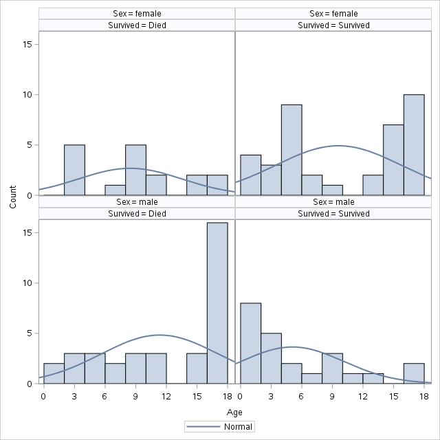

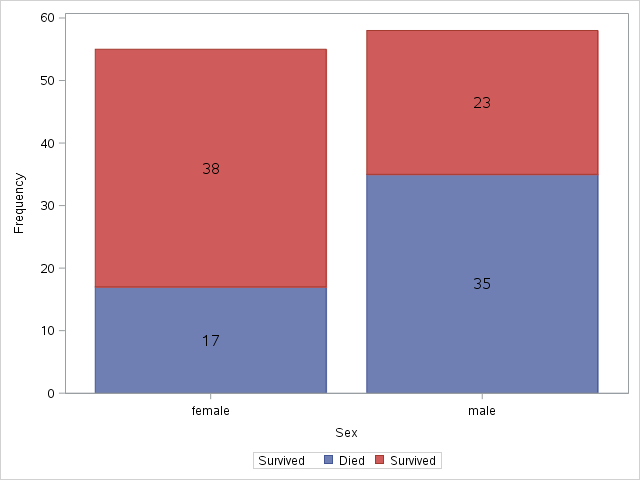

Looks similiar to the overall chart above. Shows that Minor or not, males were still less likely to survive.

Detecting Ordinal Associations - survival and socio-economic class.

The FREQ Procedure

| Frequency Percent Row Pct Col Pct |
| --- |

| Table of Pclass by Survived Pclass | Table of Pclass by Survived Survived Died | Table of Pclass by Survived Survived | Table of Pclass by Survived Survived Total |
| --- | --- | --- | --- |
| 1 | 80 8.98 37.04 14.57 | 136 15.26 62.96 39.77 | 216 24.24 |
| 2 | 97 10.89 52.72 17.67 | 87 9.76 47.28 25.44 | 184 20.65 |
| 3 | 372 41.75 75.76 67.76 | 119 13.36 24.24 34.80 | 491 55.11 |
| Total | 549 61.62 | 342 38.38 | 891 100.00 |

Statistics for Table of Pclass by Survived

| Statistic | DF | Value | Prob |
| --- | --- | --- | --- |
| Chi-Square | 2 | 102.8890 | <.0001 |
| Likelihood Ratio Chi-Square | 2 | 103.5471 | <.0001 |
| Mantel-Haenszel Chi-Square | 1 | 101.9668 | <.0001 |
| Phi Coefficient |  | 0.3398 |  |
| Contingency Coefficient |  | 0.3217 |  |
| Cramer's V |  | 0.3398 |  |

| Statistic | Value | ASE | 95% Confidence Limits |  |
| --- | --- | --- | --- | --- |
| Gamma | -0.5486 | 0.0431 | -0.6330 | -0.4643 |
| Kendall's Tau-b | -0.3235 | 0.0303 | -0.3830 | -0.2641 |
| Stuart's Tau-c | -0.3433 | 0.0327 | -0.4074 | -0.2791 |
| Somers' D C\|R | -0.2885 | 0.0273 | -0.3420 | -0.2349 |
| Somers' D R\|C | -0.3628 | 0.0341 | -0.4296 | -0.2960 |
| Pearson Correlation | -0.3385 | 0.0319 | -0.4011 | -0.2759 |
| Spearman Correlation | -0.3397 | 0.0319 | -0.4021 | -0.2772 |
| Lambda Asymmetric C\|R | 0.1637 | 0.0393 | 0.0867 | 0.2408 |
| Lambda Asymmetric R\|C | 0.0425 | 0.0391 | 0.0000 | 0.1191 |
| Lambda Symmetric | 0.0984 | 0.0353 | 0.0292 | 0.1676 |
| Uncertainty Coefficient C\|R | 0.0873 | 0.0167 | 0.0546 | 0.1199 |
| Uncertainty Coefficient R\|C | 0.0582 | 0.0112 | 0.0364 | 0.0801 |
| Uncertainty Coefficient Symmetric | 0.0699 | 0.0134 | 0.0437 | 0.0960 |

Sample Size = 891

Yes, there is a relationsip between class and survival chisq is significant and spearman is -0.3397.

Multivariate Plots And Analysis

Distribution of survival by age faceted by gender

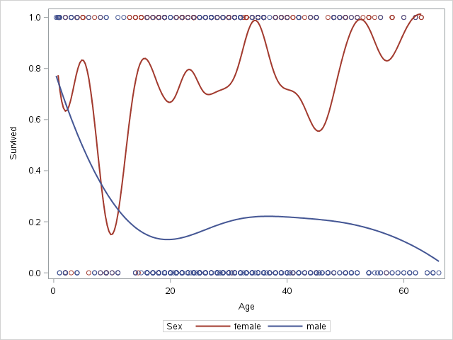

Does not look very similiar to R's plot, but proves the same point.

Let’s build a Linear probability model first.

Linear probability model: survived = age sex pclass

The GLM Procedure

| Class Level Information Class | Class Level Information Levels | Class Level Information Values |
| --- | --- | --- |
| Sex | 2 | female male |
| Pclass | 3 | 1 2 3 |

| Number of Observations Read | 891 |
| --- | --- |
| Number of Observations Used | 714 |

Linear probability model: survived = age sex pclass

The GLM Procedure

Dependent Variable: Survived

| Source | DF | Sum of Squares | Mean Square | F Value | Pr > F |
| --- | --- | --- | --- | --- | --- |
| Model | 4 | 67.1939857 | 16.7984964 | 113.41 | <.0001 |
| Error | 709 | 105.0188995 | 0.1481226 |  |  |
| Corrected Total | 713 | 172.2128852 |  |  |  |

| R-Square | Coeff Var | Root MSE | Survived Mean |
| --- | --- | --- | --- |
| 0.390180 | 94.75690 | 0.384867 | 0.406162 |

| Source | DF | Type I SS | Mean Square | F Value | Pr > F |
| --- | --- | --- | --- | --- | --- |
| Age | 1 | 1.02692222 | 1.02692222 | 6.93 | 0.0086 |
| Sex | 1 | 49.09856250 | 49.09856250 | 331.47 | <.0001 |
| Pclass | 2 | 17.06850095 | 8.53425047 | 57.62 | <.0001 |

| Source | DF | Type III SS | Mean Square | F Value | Pr > F |
| --- | --- | --- | --- | --- | --- |
| Age | 1 | 3.76045774 | 3.76045774 | 25.39 | <.0001 |
| Sex | 1 | 36.08573279 | 36.08573279 | 243.62 | <.0001 |
| Pclass | 2 | 17.06850095 | 8.53425047 | 57.62 | <.0001 |

| Parameter | Estimate |  | Standard Error | t Value | Pr > \|t\| |
| --- | --- | --- | --- | --- | --- |
| Intercept | 0.2389468762 | B | 0.03626494 | 6.59 | <.0001 |
| Age | -.0054600623 |  | 0.00108365 | -5.04 | <.0001 |
| Sex female | 0.4794556708 | B | 0.03071788 | 15.61 | <.0001 |
| Sex male | 0.0000000000 | B | . | . | . |
| Pclass 1 | 0.4066179863 | B | 0.03828823 | 10.62 | <.0001 |
| Pclass 2 | 0.1988705476 | B | 0.03640832 | 5.46 | <.0001 |
| Pclass 3 | 0.0000000000 | B | . | . | . |

Note:The X'X matrix has been found to be singular, and a generalized inverse was used to solve the normal equations. Terms whose estimates are followed by the letter 'B' are not uniquely estimable.

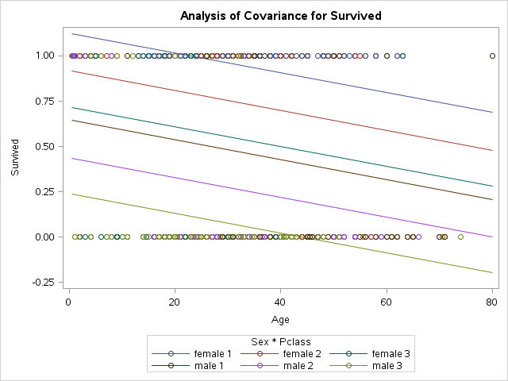

Signs make sense: Age has a negative sign, being female has a positive sign, being of higher social class has a positive sign on probability of survival.

Let’s build a logistic regression and get the odds as well.

Logistic Model (1): survived=age

The LOGISTIC Procedure

| Model Information |  |
| --- | --- |
| Data Set | WORK.TITANIC |
| Response Variable | Survived |
| Number of Response Levels | 2 |
| Model | binary logit |
| Optimization Technique | Fisher's scoring |

| Number of Observations Read | 891 |
| --- | --- |
| Number of Observations Used | 714 |

| Response Profile Ordered Value | Response Profile Survived | Response Profile Total Frequency |
| --- | --- | --- |
| 1 | 0 | 424 |
| 2 | 1 | 290 |

Probability modeled is Survived='1'.

Note:177 observations were deleted due to missing values for the response or explanatory variables.

| Model Convergence Status |
| --- |
| Convergence criterion (GCONV=1E-8) satisfied. |

| Model Fit Statistics Criterion | Model Fit Statistics Intercept Only | Model Fit Statistics Intercept and Covariates |
| --- | --- | --- |
| AIC | 966.516 | 964.228 |
| SC | 971.087 | 973.370 |
| -2 Log L | 964.516 | 960.228 |

| Testing Global Null Hypothesis: BETA=0 Test | Testing Global Null Hypothesis: BETA=0 Chi-Square | Testing Global Null Hypothesis: BETA=0 DF | Testing Global Null Hypothesis: BETA=0 Pr > ChiSq |
| --- | --- | --- | --- |
| Likelihood Ratio | 4.2876 | 1 | 0.0384 |
| Score | 4.2577 | 1 | 0.0391 |
| Wald | 4.2310 | 1 | 0.0397 |

| Analysis of Maximum Likelihood Estimates Parameter | Analysis of Maximum Likelihood Estimates DF | Analysis of Maximum Likelihood Estimates Estimate | Analysis of Maximum Likelihood Estimates Standard Error | Analysis of Maximum Likelihood Estimates Wald Chi-Square | Analysis of Maximum Likelihood Estimates Pr > ChiSq |
| --- | --- | --- | --- | --- | --- |
| Intercept | 1 | -0.0567 | 0.1736 | 0.1068 | 0.7438 |
| Age | 1 | -0.0110 | 0.00533 | 4.2310 | 0.0397 |

| Association of Predicted Probabilities and Observed Responses |  |  |  |
| --- | --- | --- | --- |
| Percent Concordant | 52.1 | Somers' D | 0.062 |
| Percent Discordant | 45.9 | Gamma | 0.063 |
| Percent Tied | 2.0 | Tau-a | 0.030 |
| Pairs | 122960 | c | 0.531 |

| Odds Ratio Estimates and Profile-Likelihood Confidence Intervals Effect | Odds Ratio Estimates and Profile-Likelihood Confidence Intervals Unit | Odds Ratio Estimates and Profile-Likelihood Confidence Intervals Estimate | Odds Ratio Estimates and Profile-Likelihood Confidence Intervals 50% Confidence Limits | Odds Ratio Estimates and Profile-Likelihood Confidence Intervals 50% Confidence Limits |
| --- | --- | --- | --- | --- |
| Age | 1.0000 | 0.989 | 0.986 | 0.993 |

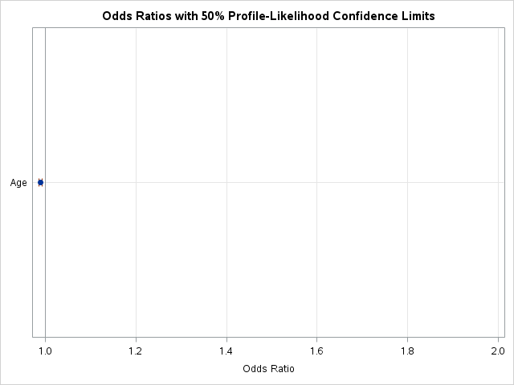

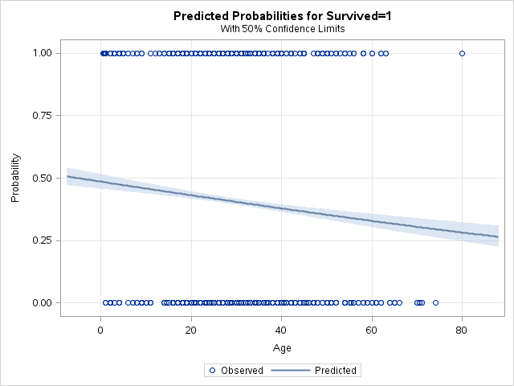

Logistic model with a categorical predictor.

Logistic Model (2): survived=age sex class

The LOGISTIC Procedure

| Model Information |  |
| --- | --- |
| Data Set | WORK.TITANIC |
| Response Variable | Survived |
| Number of Response Levels | 2 |
| Model | binary logit |
| Optimization Technique | Fisher's scoring |

| Number of Observations Read | 891 |
| --- | --- |
| Number of Observations Used | 714 |

| Response Profile Ordered Value | Response Profile Survived | Response Profile Total Frequency |
| --- | --- | --- |
| 1 | 0 | 424 |
| 2 | 1 | 290 |

Probability modeled is Survived='1'.

Note:177 observations were deleted due to missing values for the response or explanatory variables.

| Class Level Information Class | Class Level Information Value | Class Level Information Design Variables | Class Level Information Design Variables |
| --- | --- | --- | --- |
| Sex | female | 1 |  |
|  | male | 0 |  |
| Pclass | 1 | 1 | 0 |
|  | 2 | 0 | 1 |
|  | 3 | 0 | 0 |

| Model Convergence Status |
| --- |
| Convergence criterion (GCONV=1E-8) satisfied. |

| Model Fit Statistics Criterion | Model Fit Statistics Intercept Only | Model Fit Statistics Intercept and Covariates |
| --- | --- | --- |
| AIC | 966.516 | 657.283 |
| SC | 971.087 | 680.138 |
| -2 Log L | 964.516 | 647.283 |

| Testing Global Null Hypothesis: BETA=0 Test | Testing Global Null Hypothesis: BETA=0 Chi-Square | Testing Global Null Hypothesis: BETA=0 DF | Testing Global Null Hypothesis: BETA=0 Pr > ChiSq |
| --- | --- | --- | --- |
| Likelihood Ratio | 317.2328 | 4 | <.0001 |
| Score | 278.5884 | 4 | <.0001 |
| Wald | 191.2608 | 4 | <.0001 |

| Type 3 Analysis of Effects Effect | Type 3 Analysis of Effects DF | Type 3 Analysis of Effects Wald Chi-Square | Type 3 Analysis of Effects Pr > ChiSq |
| --- | --- | --- | --- |
| Age | 1 | 23.3376 | <.0001 |
| Sex | 1 | 147.9716 | <.0001 |
| Pclass | 2 | 85.6039 | <.0001 |

| Analysis of Maximum Likelihood Estimates Parameter | Analysis of Maximum Likelihood Estimates | Analysis of Maximum Likelihood Estimates DF | Analysis of Maximum Likelihood Estimates Estimate | Analysis of Maximum Likelihood Estimates Standard Error | Analysis of Maximum Likelihood Estimates Wald Chi-Square | Analysis of Maximum Likelihood Estimates Pr > ChiSq |
| --- | --- | --- | --- | --- | --- | --- |
| Intercept |  | 1 | -1.3264 | 0.2479 | 28.6297 | <.0001 |
| Age |  | 1 | -0.0370 | 0.00766 | 23.3376 | <.0001 |
| Sex | female | 1 | 2.5228 | 0.2074 | 147.9716 | <.0001 |
| Pclass | 1 | 1 | 2.5806 | 0.2814 | 84.0755 | <.0001 |
| Pclass | 2 | 1 | 1.2708 | 0.2440 | 27.1156 | <.0001 |

| Association of Predicted Probabilities and Observed Responses |  |  |  |
| --- | --- | --- | --- |
| Percent Concordant | 85.1 | Somers' D | 0.705 |
| Percent Discordant | 14.6 | Gamma | 0.706 |
| Percent Tied | 0.3 | Tau-a | 0.340 |
| Pairs | 122960 | c | 0.852 |

| Odds Ratio Estimates and Profile-Likelihood Confidence Intervals Effect | Odds Ratio Estimates and Profile-Likelihood Confidence Intervals Unit | Odds Ratio Estimates and Profile-Likelihood Confidence Intervals Estimate | Odds Ratio Estimates and Profile-Likelihood Confidence Intervals 50% Confidence Limits | Odds Ratio Estimates and Profile-Likelihood Confidence Intervals 50% Confidence Limits |
| --- | --- | --- | --- | --- |
| Age | 10.0000 | 0.691 | 0.656 | 0.727 |
| Sex female vs male | 1.0000 | 12.463 | 10.847 | 14.350 |
| Pclass 1 vs 3 | 1.0000 | 13.205 | 10.939 | 15.992 |
| Pclass 2 vs 3 | 1.0000 | 3.564 | 3.024 | 4.204 |

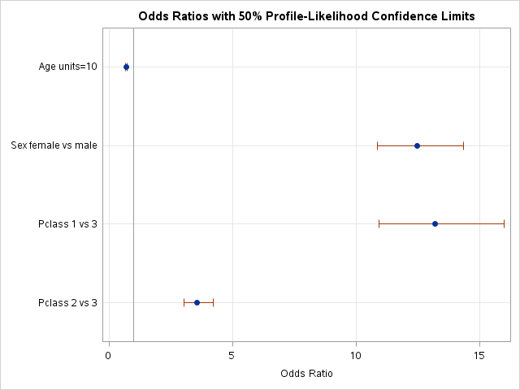

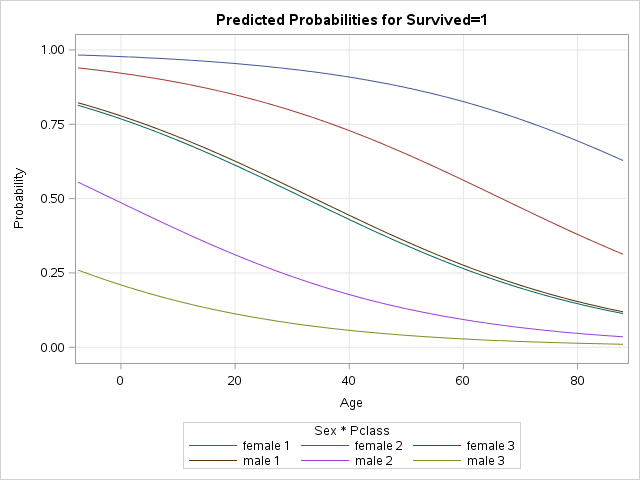

Interpretation of odds ratios: Increasing age by 10 years decreases the odds of surviving by 0.691, going from male to female increases the odds by 12.463, going from Pllass=3 to 1 increases the odds by 13.205 etc.

Logistic regression: backward elimination with interactions.

Logistic Model (3): Backward elimination, survived=age sex class

The LOGISTIC Procedure

| Model Information |  |
| --- | --- |
| Data Set | WORK.TITANIC |
| Response Variable | Survived |
| Number of Response Levels | 2 |
| Model | binary logit |
| Optimization Technique | Fisher's scoring |

| Number of Observations Read | 891 |
| --- | --- |
| Number of Observations Used | 714 |

| Response Profile Ordered Value | Response Profile Survived | Response Profile Total Frequency |
| --- | --- | --- |
| 1 | 0 | 424 |
| 2 | 1 | 290 |

Probability modeled is Survived='1'.

Note:177 observations were deleted due to missing values for the response or explanatory variables.

Backward Elimination Procedure

| Class Level Information Class | Class Level Information Value | Class Level Information Design Variables | Class Level Information Design Variables |
| --- | --- | --- | --- |
| Sex | female | 1 |  |
|  | male | 0 |  |
| Pclass | 1 | 1 | 0 |
|  | 2 | 0 | 1 |
|  | 3 | 0 | 0 |

Step 0. The following effects were entered:

Intercept Age Sex Age*Sex Pclass Age*Pclass Sex*Pclass

| Model Convergence Status |
| --- |
| Convergence criterion (GCONV=1E-8) satisfied. |

| Model Fit Statistics Criterion | Model Fit Statistics Intercept Only | Model Fit Statistics Intercept and Covariates |
| --- | --- | --- |
| AIC | 966.516 | 624.335 |
| SC | 971.087 | 670.044 |
| -2 Log L | 964.516 | 604.335 |

| Testing Global Null Hypothesis: BETA=0 Test | Testing Global Null Hypothesis: BETA=0 Chi-Square | Testing Global Null Hypothesis: BETA=0 DF | Testing Global Null Hypothesis: BETA=0 Pr > ChiSq |
| --- | --- | --- | --- |
| Likelihood Ratio | 360.1806 | 9 | <.0001 |
| Score | 307.0826 | 9 | <.0001 |
| Wald | 160.2179 | 9 | <.0001 |

Step 1. Effect Age*Sex is removed:

| Model Convergence Status |
| --- |
| Convergence criterion (GCONV=1E-8) satisfied. |

| Model Fit Statistics Criterion | Model Fit Statistics Intercept Only | Model Fit Statistics Intercept and Covariates |
| --- | --- | --- |
| AIC | 966.516 | 624.925 |
| SC | 971.087 | 666.063 |
| -2 Log L | 964.516 | 606.925 |

| Testing Global Null Hypothesis: BETA=0 Test | Testing Global Null Hypothesis: BETA=0 Chi-Square | Testing Global Null Hypothesis: BETA=0 DF | Testing Global Null Hypothesis: BETA=0 Pr > ChiSq |
| --- | --- | --- | --- |
| Likelihood Ratio | 357.5914 | 8 | <.0001 |
| Score | 305.0076 | 8 | <.0001 |
| Wald | 155.8008 | 8 | <.0001 |

| Residual Chi-Square Test Chi-Square | Residual Chi-Square Test DF | Residual Chi-Square Test Pr > ChiSq |
| --- | --- | --- |
| 2.6085 | 1 | 0.1063 |

Step 2. Effect Age*Pclass is removed:

| Model Convergence Status |
| --- |
| Convergence criterion (GCONV=1E-8) satisfied. |

| Model Fit Statistics Criterion | Model Fit Statistics Intercept Only | Model Fit Statistics Intercept and Covariates |
| --- | --- | --- |
| AIC | 966.516 | 627.427 |
| SC | 971.087 | 659.423 |
| -2 Log L | 964.516 | 613.427 |

| Testing Global Null Hypothesis: BETA=0 Test | Testing Global Null Hypothesis: BETA=0 Chi-Square | Testing Global Null Hypothesis: BETA=0 DF | Testing Global Null Hypothesis: BETA=0 Pr > ChiSq |
| --- | --- | --- | --- |
| Likelihood Ratio | 351.0893 | 6 | <.0001 |
| Score | 304.0535 | 6 | <.0001 |
| Wald | 165.8907 | 6 | <.0001 |

| Residual Chi-Square Test Chi-Square | Residual Chi-Square Test DF | Residual Chi-Square Test Pr > ChiSq |
| --- | --- | --- |
| 8.5217 | 3 | 0.0364 |

Note:No (additional) effects met the 0.01 significance level for removal from the model.

| Summary of Backward Elimination Step | Summary of Backward Elimination Effect Removed | Summary of Backward Elimination DF | Summary of Backward Elimination Number In | Summary of Backward Elimination Wald Chi-Square | Summary of Backward Elimination Pr > ChiSq |
| --- | --- | --- | --- | --- | --- |
| 1 | Age*Sex | 1 | 5 | 2.5867 | 0.1078 |
| 2 | Age*Pclass | 2 | 4 | 5.8291 | 0.0542 |

| Joint Tests Effect | Joint Tests DF | Joint Tests Wald Chi-Square | Joint Tests Pr > ChiSq |
| --- | --- | --- | --- |
| Age | 1 | 26.2539 | <.0001 |
| Sex | 1 | 28.2477 | <.0001 |
| Pclass | 2 | 43.8036 | <.0001 |
| Sex*Pclass | 2 | 28.8486 | <.0001 |

Note:Under full-rank parameterizations, Type 3 effect tests are replaced by joint tests. The joint test for an effect is a test that all the parameters associated with that effect are zero. Such joint tests might not be equivalent to Type 3 effect tests under GLM parameterization.

| Analysis of Maximum Likelihood Estimates Parameter | Analysis of Maximum Likelihood Estimates | Analysis of Maximum Likelihood Estimates | Analysis of Maximum Likelihood Estimates DF | Analysis of Maximum Likelihood Estimates Estimate | Analysis of Maximum Likelihood Estimates Standard Error | Analysis of Maximum Likelihood Estimates Wald Chi-Square | Analysis of Maximum Likelihood Estimates Pr > ChiSq |
| --- | --- | --- | --- | --- | --- | --- | --- |
| Intercept |  |  | 1 | -0.7059 | 0.2575 | 7.5153 | 0.0061 |
| Age |  |  | 1 | -0.0419 | 0.00818 | 26.2539 | <.0001 |
| Sex | female |  | 1 | 1.4466 | 0.2722 | 28.2477 | <.0001 |
| Pclass | 1 |  | 1 | 1.9765 | 0.3099 | 40.6808 | <.0001 |
| Pclass | 2 |  | 1 | 0.1473 | 0.3385 | 0.1892 | 0.6636 |
| Sex*Pclass | female | 1 | 1 | 2.1926 | 0.6853 | 10.2380 | 0.0014 |
| Sex*Pclass | female | 2 | 1 | 2.8615 | 0.5910 | 23.4394 | <.0001 |

| Association of Predicted Probabilities and Observed Responses |  |  |  |
| --- | --- | --- | --- |
| Percent Concordant | 86.0 | Somers' D | 0.723 |
| Percent Discordant | 13.7 | Gamma | 0.724 |
| Percent Tied | 0.3 | Tau-a | 0.349 |
| Pairs | 122960 | c | 0.861 |

| Odds Ratio Estimates and Profile-Likelihood Confidence Intervals Effect | Odds Ratio Estimates and Profile-Likelihood Confidence Intervals Unit | Odds Ratio Estimates and Profile-Likelihood Confidence Intervals Estimate | Odds Ratio Estimates and Profile-Likelihood Confidence Intervals 50% Confidence Limits | Odds Ratio Estimates and Profile-Likelihood Confidence Intervals 50% Confidence Limits |
| --- | --- | --- | --- | --- |
| Age | 10.0000 | 0.657 | 0.622 | 0.695 |

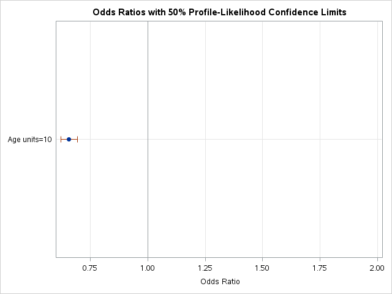

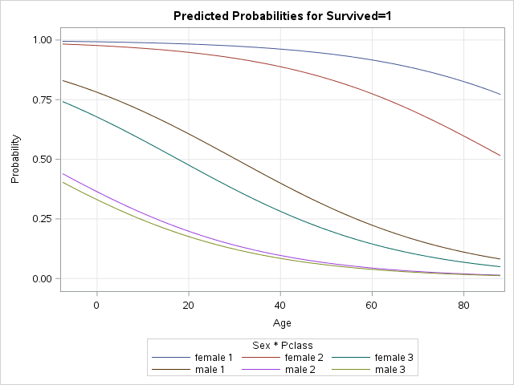

Plot empirical estimated logits - to verify if the assumption of linear holds.

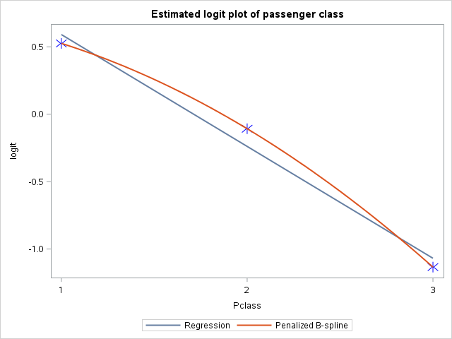

Looks sort of linear, so logistic regression is applicable.

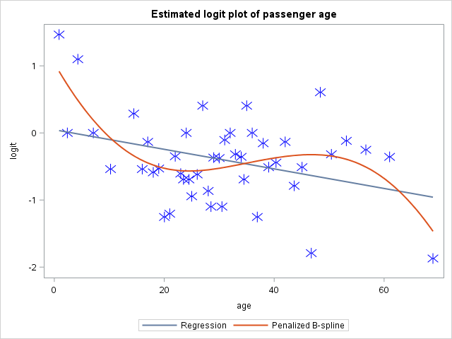

Nonlinearity detected - perhaps we need to transform Age before plugging into a logistic regression.

Final Plots and Summary.

Plot One: Bar chart of Survived and Gender.

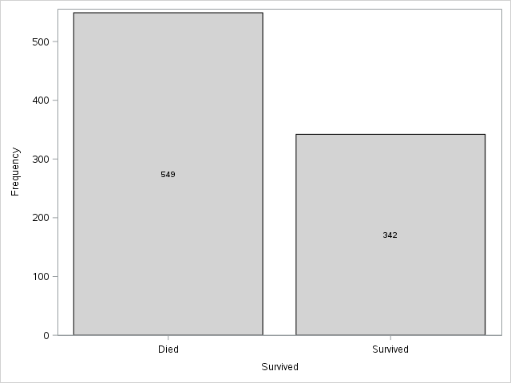

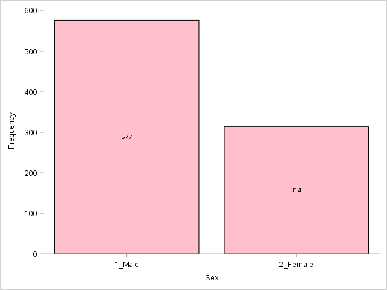

| Survived | count | percent |
| --- | --- | --- |
| 0 | 549 | 62% |
| 1 | 342 | 38% |

| Sex | count | percent |
| --- | --- | --- |
| male | 577 | 65% |
| female | 314 | 35% |

Plot One Discussion.

Interesting, the distributions of Survived and Sex are almost identical.

That is 65pct of passengers were male and 62pct of passengers did not survive.

Is there a link between being male and not surviving?

Plot Two: Distribution of Age by Survived separately by Sex.

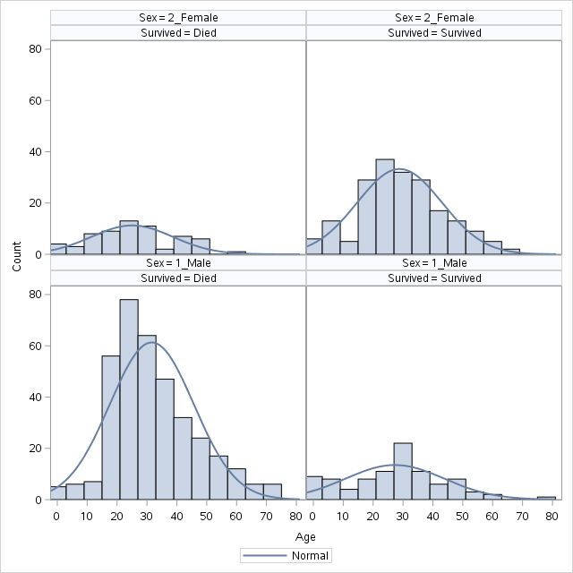

Plot Two Discussion.

This plot looks like a mirror image: most of men did not survive, while most women did.

Plot Three: Linear probability model by Sex.

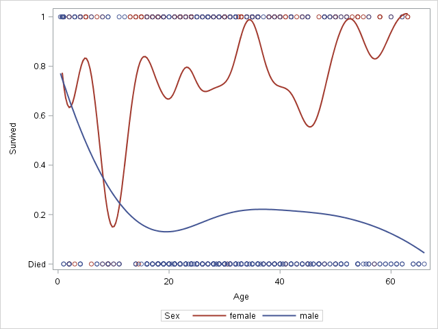

Plot Three Discussion.

Issues, Reflections, Conclusions (Speculations)

Issues: What we have is an incomplete data set - obviously there were more than 891 passengers on Titanic. We can make no assumptions about whether we got a random sample or a biased one. Therefore we cannot really make any general conclusions but we can speculate about the results.

There is missing data for Age. I did no imputations because I cannot make any assumptions whether the values are MCAR (missing completely at random). Those observations were just dropped by the R’s procedures when Age variable was invovled.

My exploratory data analysis suggested a link between survival and gender, so I pursued this and conducted statistical tests.

Chi-squared test of the frequency of survival based on gender (Sex) returned a very low p-value meaning this pattern could not have occurred by chance.

Both the linear and logistic probability models returned negative estimates for being male on survival.

The odds ratio of survival of being female comparing to being a male was 12.5.

This means that females were 12 times more likely to survive that males.

This pattern holds even for minors (<18 years old) - females were still more likely to survive.

This seems to suggest that in the good old saying “women and children first” boys of 15 years or older do not count as “children.”

Next steps? In the future I could review other tragic events and disasters and analyze factors that influence the probability of survival.

Appendix: Data Dictionary

Data source: https://www.kaggle.com/c/titanic/data

VARIABLE DESCRIPTIONS:

survival Survival

(0 = No; 1 = Yes)

pclass Passenger Class

(1 = 1st; 2 = 2nd; 3 = 3rd)

name Name

sex Sex

age Age

sibsp Number of Siblings/Spouses Aboard

parch Number of Parents/Children Aboard

ticket Ticket Number

fare Passenger Fare

cabin Cabin

embarked Port of Embarkation

(C = Cherbourg; Q = Queenstown; S = Southampton)

The End.